# Reproducible Research: Peer Assessment 1

Alex

2016-08-04

## Loading and preprocessing the data

First of all loading libraries

```r
library( data.table)
library( dplyr)
```

```r
dt <- fread( input = "./activity.csv")
```

There is no real need to process/transform the data at this stage. Removing NAs option will be done later on in this assignment.

Also did a visual exploration of data with my favorite spreadsheet soft (LibreOffice Calc).

## What is mean total number of steps taken per day?

The average total number of steps per day for the period is the sum of all steps par day divided by the number of dates :

```r
sum( dt$steps, na.rm = TRUE) / length( unique( dt$date))
```

```
## [1] 9354.23
```

#### 2 Make a histogram of the total number of steps taken each day

The total number of steps per day for every day is :

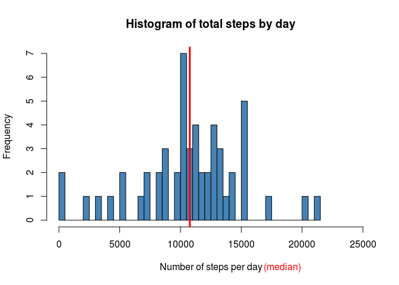

```r
StepsDay <- aggregate(steps ~ date, data = dt, sum, na.rm = TRUE)
par( mfrow = c( 1, 1))
hist( StepsDay$steps,
      main = "Histogram of total steps by day",
      xlab = "Number of steps per day",
      breaks = 50,
      xlim = c( 0, 25000),
      col = "SteelBlue")
abline( v = median( StepsDay$steps, na.rm = TRUE), col = "red", lwd = 3)
mtext( side = 1, col = "red", line = 3,
       text = paste( "                                ",
                     "                           (median)"))
```

The mean is :

```r
mean( StepsDay$steps)
```

```
## [1] 10766.19
```

And the median is :

```r
median( StepsDay$steps)
```

```
## [1] 10765
```

They are almost identical and represented by the red line on the graph.

## What is the average daily activity pattern?

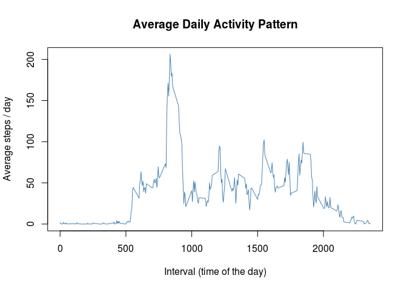

```r
dt2 <- dt %>%
       group_by( interval) %>%
       summarize( avedays = mean( steps, na.rm=TRUE))

plot( dt2$interval, dt2$avedays,
                    type="l",
                    col="SteelBlue",
                    main="Average Daily Activity Pattern",
                    xlab="Interval (time of the day)",
                    ylab="Average steps / day")
```

The max number of averaged steps per day is for interval :

```r
as.numeric( as.character( dt2[ which( dt2$avedays == max( dt2$avedays)), "interval"]$interval))
```

```
## [1] 835
```

## Imputing missing values

The percent of NAs in the data set is :

```r
paste0( sprintf( fmt = "%2.f",
                 sum( is.na( dt$steps)) * 100 / nrow( dt)),
        "%")
```

```
## [1] "13%"
```

```r
dt3 <- dt
AverageSteps <- sum( dt$steps, na.rm = TRUE) /  length( dt$date)
dt3$steps[ is.na( dt3$steps)] <- AverageSteps
```

The total number of steps per day for every day is :

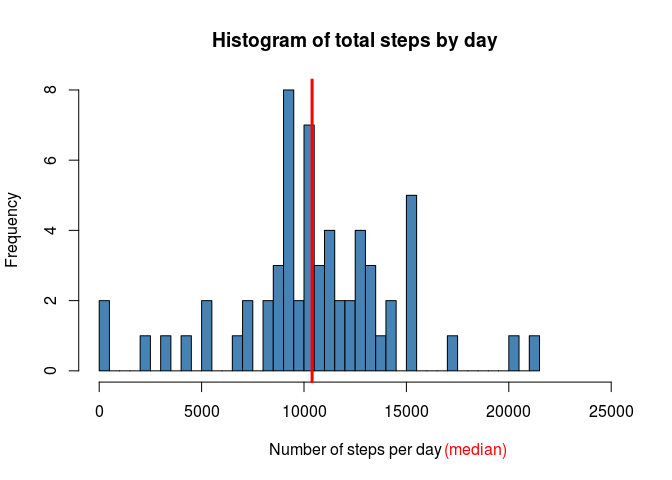

```r
StepsDay <- aggregate(steps ~ date, data = dt3, sum, na.rm = TRUE)
par( mfrow = c( 1, 1))
hist( StepsDay$steps,
      main = "Histogram of total steps by day",
      xlab = "Number of steps per day",
      breaks = 50,
      xlim = c( 0, 25000),
      col = "SteelBlue")
abline( v = median( StepsDay$steps, na.rm = TRUE), col = "red", lwd = 3)
mtext( side = 1, col = "red", line = 3,
       text = paste( "                                ",
                     "                           (median)"))
```

The mean is :

```r
mean( StepsDay$steps)
```

```
## [1] 10581.01
```

And the median is :

```r
median( StepsDay$steps)
```

```
## [1] 10395
```

## Are there differences in activity patterns between weekdays and weekends?

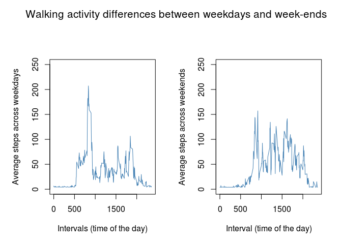

```r
dt3$days <- weekdays( as.Date( dt3$date))
dt3$days <- factor( dt3$days,
                    levels = c( "lundi",
                                "mardi",
                                "mercredi",
                                "jeudi",
                                "vendredi",
                                "samedi",
                                "dimanche"),
                    ordered = TRUE)
weekdays <- c( "lundi",
               "mardi",
               "mercredi",
               "jeudi",
               "vendredi")
weekends <- c( "samedi", "dimanche")

dt3$wd[ dt3$days %in% weekdays] <- "weekday"
dt3$wd[ dt3$days %in% weekends] <- "weekend"
dt3$wd <- factor( dt3$wd,
                    levels = c( "weekday", "weekend"),
                    ordered = TRUE)
par( mfrow = c( 1,2))
par( oma = c( 0, 1, 2, 0))

tssteps3 <- ts( dt3 %>%
                  filter( wd == "weekday") %>%
                  group_by( interval) %>%
                  summarize( mean( steps, na.rm = TRUE)))

plot( tssteps3[ , 1], tssteps3[ , 2] , type = "l",
      xlab = "Intervals (time of the day)",
      ylab = "Average steps across weekdays",
      col = "SteelBlue",
      ylim = c( 0, 250))


tssteps3 <- ts( dt3 %>%
                  filter( wd == "weekend") %>%
                  group_by( interval) %>%
                  summarize( mean( steps, na.rm = TRUE)))

plot( tssteps3[ , 1], tssteps3[ , 2] , type = "l",
      xlab = "Interval (time of the day)",
      ylab = "Average steps across weekends",
      col = "SteelBlue",
      ylim = c( 0, 250))


mtext( text = paste( "Walking activity differences",
                     "between weekdays and week-ends"),
       side = 3,
       cex = 1.3,
       line = 0,
       outer = TRUE)
```

### ————————————————————————————————–